# STA 260 Final Project

Yimin Yang

5/28/2021

# Exploratory Data Analysis

## Loading CDC dataset

Load CDC dataset (subset where state is labelled CA):

```r
ca_covid <- read.csv("CA_combined_csv.csv",
                     encoding = "UTF-8-BOM",
                     na.strings=c('NA', '', 'Missing', 'N/A', 'Unknown'),
                     stringsAsFactors=TRUE)
```

## Cleaning Dataset

Fixing data entry errors

Also add a column to indicate high risk cases (whether the patient died, was hospitalized, or was in the ICU)

Note that missing data is excluded for all of the diagrams

```r
#fix column name
names(ca_covid)[1] = "race_ethnicity_combined"

# combine upper case and lower case counties together
ca_covid$res_county = as.factor(toupper(ca_covid$res_county))

#remove observation with data entry error
ca_covid = ca_covid[-which(ca_covid$cdc_case_earliest_dt=="1960-09-29"),]

#change date variables from factors to dates
ca_covid$cdc_case_earliest_dt = as.Date(ca_covid$cdc_case_earliest_dt)
ca_covid$cdc_report_dt = as.Date(ca_covid$cdc_case_earliest_dt)

#fix data entry errors
ca_covid[which(ca_covid$res_county=="BERKELEY"),]$res_county = "ALAMEDA"
ca_covid[which(ca_covid$res_county=="LONG BEACH"),]$res_county = "LOS ANGELES"
ca_covid[which(ca_covid$res_county=="PASADENA"),]$res_county = "LOS ANGELES"

#list of counties in california
ca_counties = c("ALAMEDA", "ALPINE", "AMADOR", "BUTTE", "CALAVERAS",
                "COLUSA", "CONTRA COSTA", "DEL NORTE", "EL DORADO",
                "FRESNO", "GLENN", "HUMBOLDT", "IMPERIAL", "INYO",
                "KERN", "KINGS", "LAKE", "LASSEN", "LOS ANGELES",
                "MADERA", "MARIN", "MARIPOSA", "MENDOCINO", "MERCED",
                "MODOC", "MONO", "MONTEREY", "NAPA", "NEVADA", "ORANGE",
                "PLACER", "PLUMAS", "RIVERSIDE", "SARCRAMENTO", "SAN BENITO",
                "SAN BERNARDINO", "SAN DIEGO", "SAN FRANCISCO", "SAN JOAQUIN",
                "SAN LUIS OBISPO", "SAN MATEO", "SANTA BARBARA", "SANTA CLARA",
                "SANTA CRUZ", "SHASTA", "SIERRA", "SISKIYOU", "SOLANO", "SONOMA",
                "STANISLAUS", "SUTTER", "TEHAMA", "TRINITY", "TULARE",
                "TUOLUMNE", "VENTURA", "YOLO", "YUBA")
#remove non-CA counties
ca_covid = ca_covid[ca_covid$res_county %in% ca_counties, ]
ca_covid$res_county = droplevels(ca_covid$res_county)

#add column for high risk cases (if the case died, was hospitalized, or was in ICU)
ca_covid$high_risk = ifelse(ca_covid$hosp_yn=="Yes" |
                              ca_covid$death_yn=="Yes" |
                              ca_covid$icu_yn=="Yes", "Yes", "No")
ca_covid$high_risk = as.factor(ca_covid$high_risk)
```

## Cases by Month Line Plots

In terms of case numbers (not normalized with population of county), LA county has by far the greatest number of cases, deaths, and high risk patients

```r
# dataset to summarize cases/deaths/hosp/icu counts by county and month
cases_by_month = ca_covid %>%
  group_by(res_county, month=floor_date(cdc_case_earliest_dt, "month")) %>%
  summarise(count=n(), deaths=sum(death_yn=="Yes", na.rm=TRUE),
            hosp=sum(hosp_yn=="Yes", na.rm=TRUE),
            icu=sum(icu_yn=="Yes", na.rm=TRUE),
            high_risk=(sum(high_risk=="Yes", na.rm=TRUE)))
```

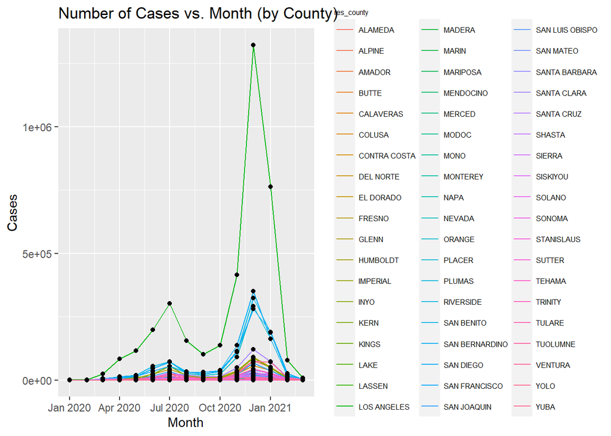

```r
# load county population dataset and combine datasets
ca_pop <- read.csv("ca_population.csv")
names(ca_pop)[1] = "county"
ca_pop$Population = ca_pop$Population/100000
ca_pop$county = toupper(ca_pop$county)
cases_by_month = left_join(cases_by_month, ca_pop, by = c("res_county" = "county"))

#line plots

ggplot(cases_by_month, aes(x=month, y=count, group=res_county))+
  geom_line(aes(color=res_county))+
  geom_point()+
  ggtitle("Number of Cases vs. Month (by County)")+
  xlab("Month")+
  ylab("Cases")+
  theme(legend.title = element_text(size = 6),
               legend.text = element_text(size = 6))
```

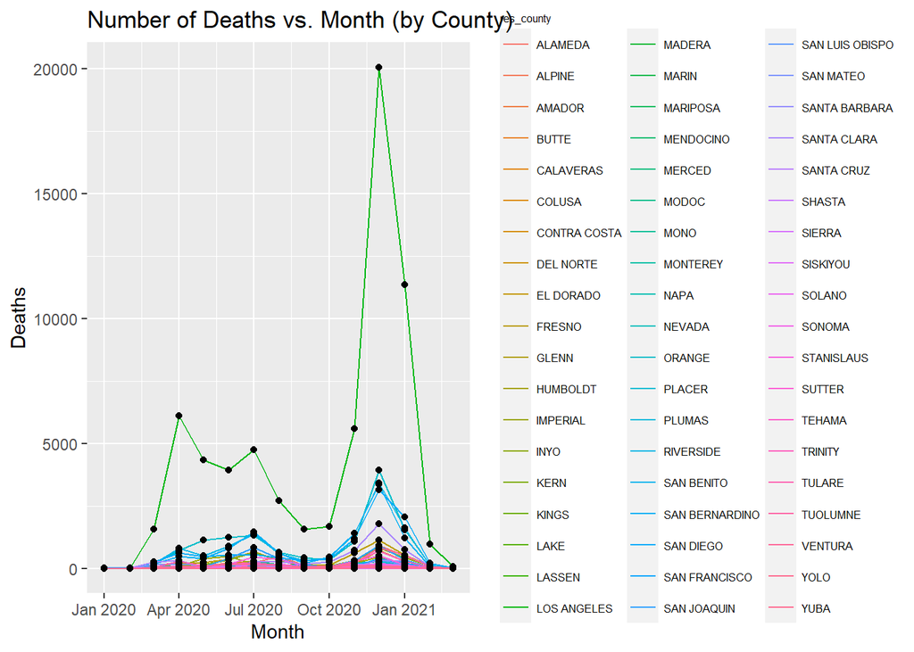

```r
ggplot(cases_by_month, aes(x=month, y=deaths, group=res_county))+
  geom_line(aes(color=res_county))+
  geom_point()+
  ggtitle("Number of Deaths vs. Month (by County)")+
  xlab("Month")+
  ylab("Deaths")+
  theme(legend.title = element_text(size = 6),
               legend.text = element_text(size = 6))
```

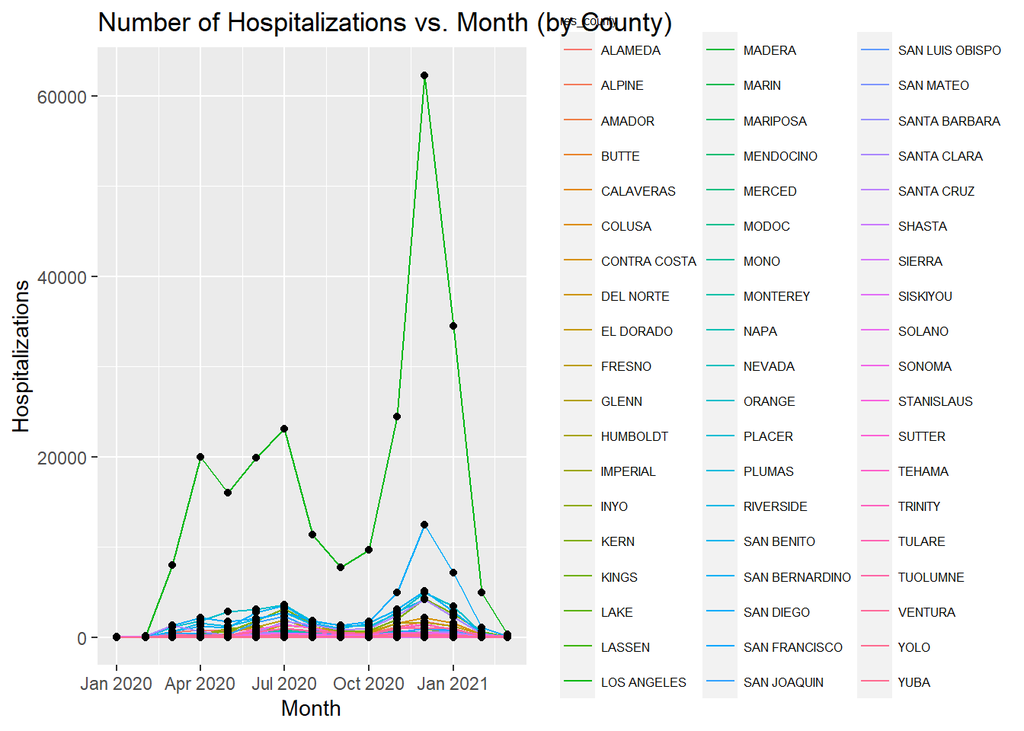

```r
ggplot(cases_by_month, aes(x=month, y=hosp, group=res_county))+
  geom_line(aes(color=res_county))+
  geom_point()+
  ggtitle("Number of Hospitalizations vs. Month (by County)")+
  xlab("Month")+
  ylab("Hospitalizations")+
  theme(legend.title = element_text(size = 6),
               legend.text = element_text(size = 6))
```

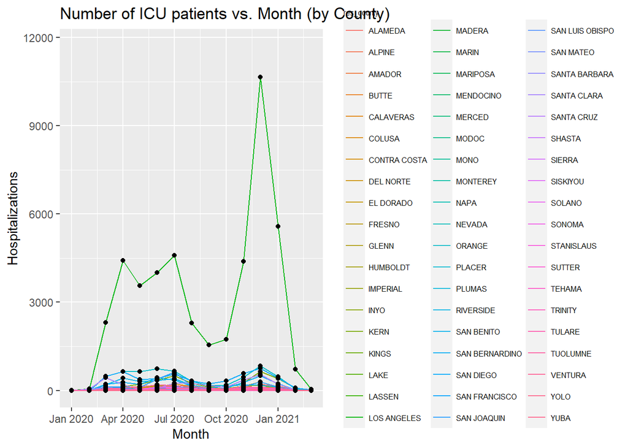

```r
ggplot(cases_by_month, aes(x=month, y=icu, group=res_county))+
  geom_line(aes(color=res_county))+
  geom_point()+
  ggtitle("Number of ICU patients vs. Month (by County)")+
  xlab("Month")+
  ylab("Hospitalizations")+
  theme(legend.title = element_text(size = 6),
               legend.text = element_text(size = 6))
```

## Heatmaps of Cases/Deaths/Hospitalizations/ICU by County and Month

Counts were divided by the population of the county. There are two noticeable peaks in July 2020 and December 2020, which correspond to the two big waves of COVID. After normalizing by population, LA county still has a high death/hospitalization/ICU rate. The peaks are not as apparent in the ICU heatmap which may be due to the large amount of missing data for this variable.

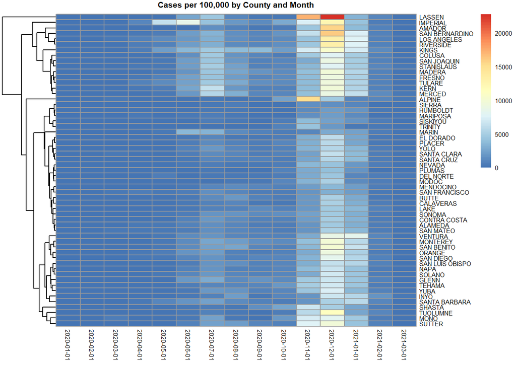

```r
#heatmap of cases/100,000 county population by county and month
pheatmap(xtabs(count/Population~res_county+month, cases_by_month), cluster_cols=FALSE, fontsize =6, main="Cases per 100,000 by County and Month")
```

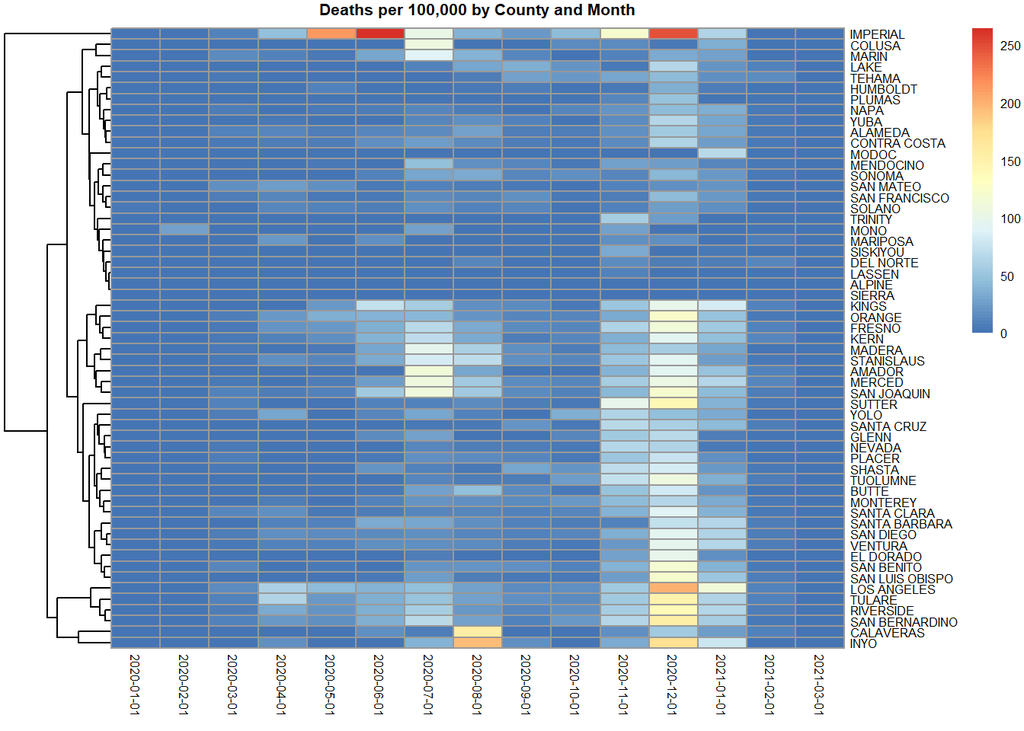

```r
#heatmap of deaths/100,000 people in county by county and month
pheatmap(xtabs(deaths/Population~res_county+month, cases_by_month), cluster_cols=FALSE, fontsize =6, main="Deaths per 100,000 by County and Month")
```

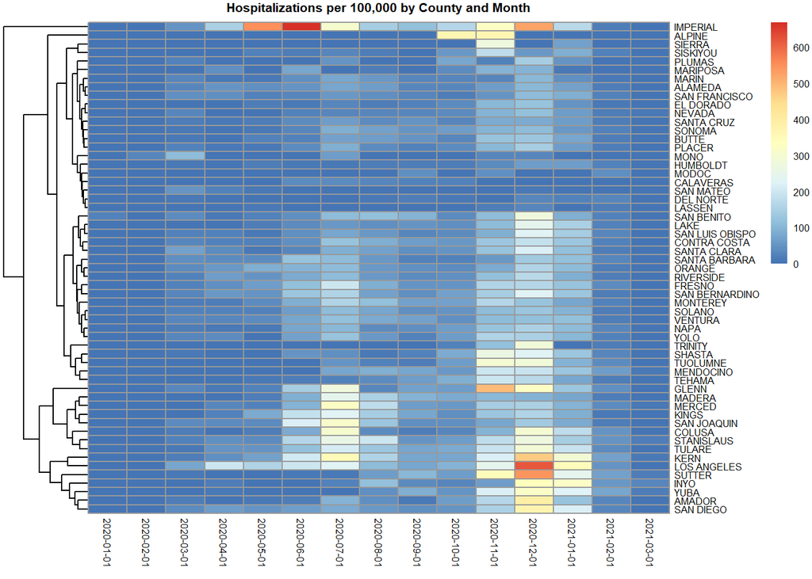

```r
#heatmap of hospitalizations/100,000 people in county by county and month
pheatmap(xtabs(hosp/Population~res_county+month, cases_by_month), cluster_cols=FALSE, fontsize =6, main="Hospitalizations per 100,000 by County and Month")
```

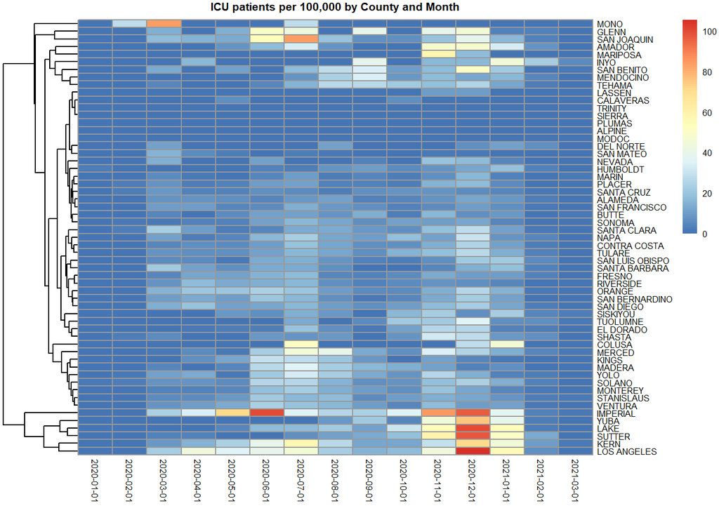

```r
#heatmap of icu patients/100,000 people in county by county and month
pheatmap(xtabs(icu/Population~res_county+month, cases_by_month), cluster_cols=FALSE, fontsize =6, main="ICU patients per 100,000 by County and Month")
```